# Roots

# 2 SSA

Посмотрим на график собственных чисел всего ряда.

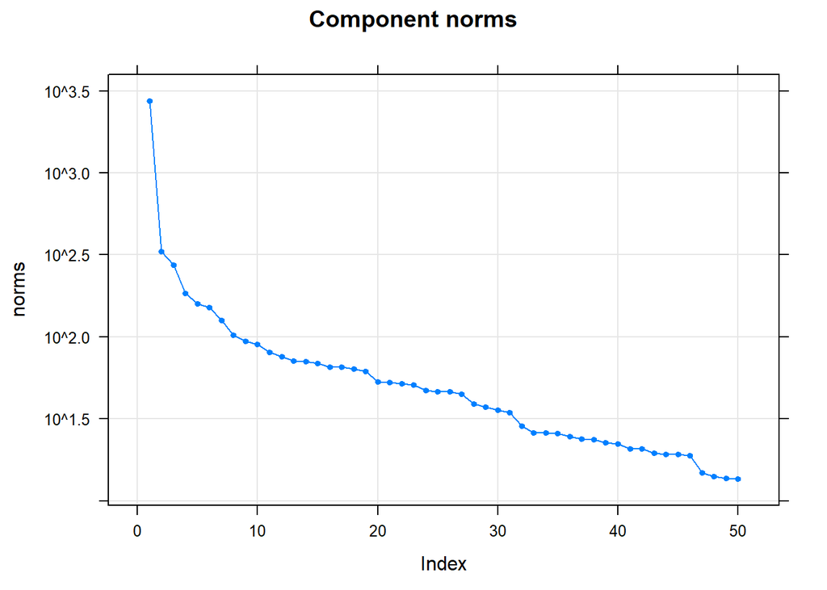

```r
Women.ssa<-ssa(tsWomen,L=420)
plot(Women.ssa)
```

График не очень приятный. Будет сложно отделить сигнал от шума (собственные числа близки).

Как показали эксперименты, сразу делать ssa для нашего ряда – это ужас. Тренд вылезает всюду и вне очереди (как мы и ожидали, посмотрев на предыдущий график, все перемешалось. Этого можно было ожидать и на основе периодограммы, там все пики примерно одинаковой величины). И рассматривать нам придется очень много собственных векторов. Поэтому лучше сначала выделим тренд, а потом остаток разделим на периодичность и шум.

Будем применять последовательный SSA. Для выделения тренда возьмем небольшую длину окна.

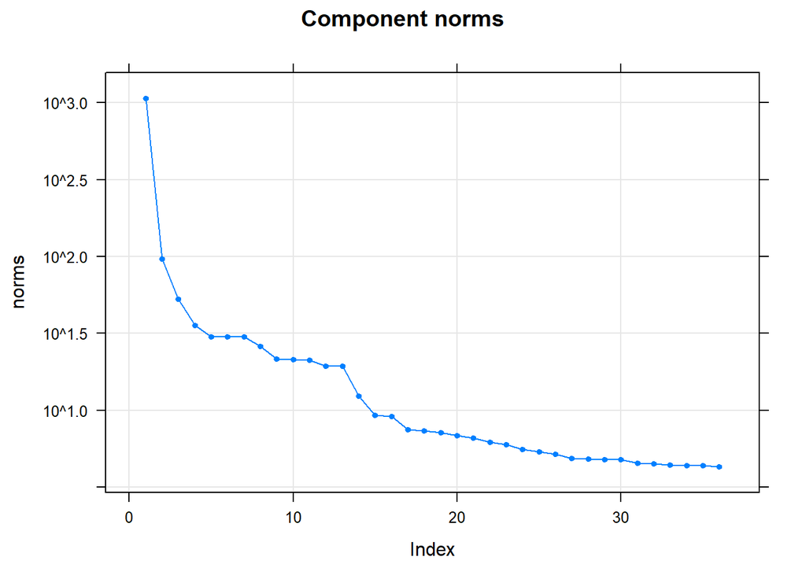

```r
trend.SSA<-ssa(tsWomen,L=36)
plot(trend.SSA)
```

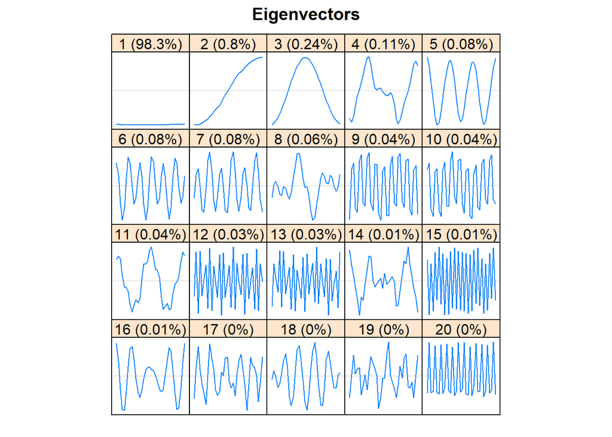

```r
plot(trend.SSA,type="vectors",idx=1:20)
```

Первые три компоненты есть тренд.

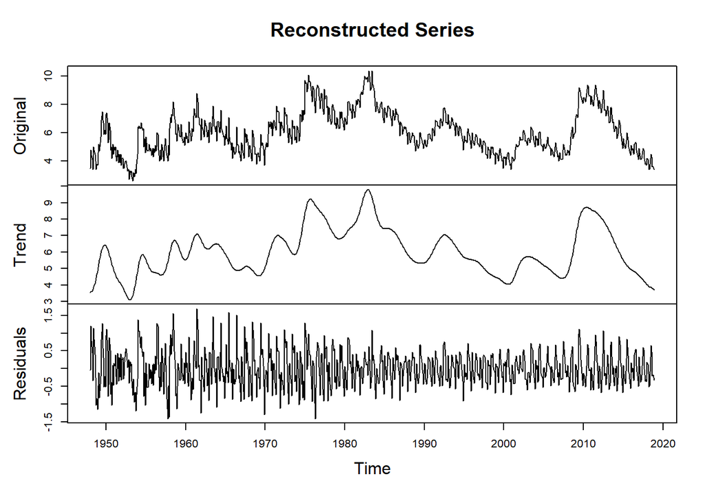

```r
plot(reconstruct(trend.SSA, groups = list(Trend=c(1:3)),
     plot.method = "xyplot", layout = c(1,7),
     add.residuals = FALSE, add.original = FALSE))
```

```r
trend.ssa.reconstruct<-reconstruct(trend.SSA, groups = list(Trend = 1:3))
Women.trend<-trend.ssa.reconstruct$Trend
```

Переходим к анализу ряда без тренда.

```r
Women.detrend<-ts(tsWomen-Women.trend,frequency = 12)
Women.detrend.ssa<-ssa(Women.detrend,L=420)
```

Построим периодограмму для полученного ряда без тренда:

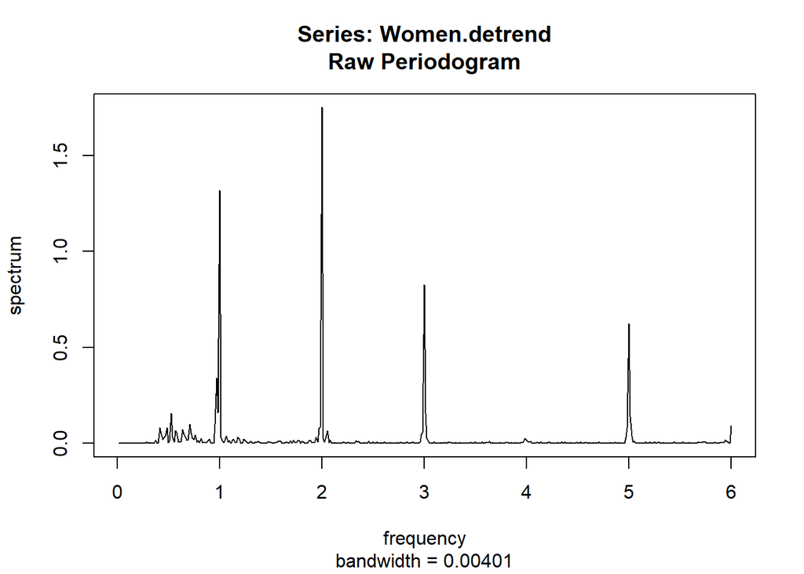

```r
spec.pgram(Women.detrend,log='no')
```

Как мы видели и раньше, присутствуют периоды 12, 6, 4, 2.4. И теперь еще немного выделились периоды 2 и 3, которых на периодограмме исходного ряда было не видно (из-за масштаба). Так что далее будем искать в том числе и пилу. И заметны повышенные низкие частоты.

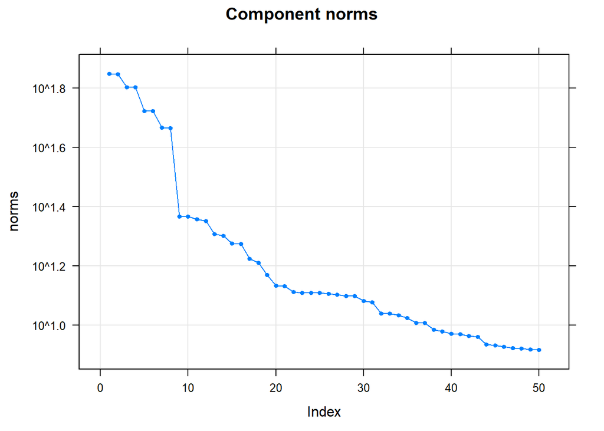

```r
plot(Women.detrend.ssa)
```

Четыре пары выделяются сильно. Но нет уверенности в том, что они возьмут всю периодичность (точнее, точно не возьмут, хотя бы потому, что мы теперь обнаружили больше периодов в ряде). Но сначала разберемся с очевидными.

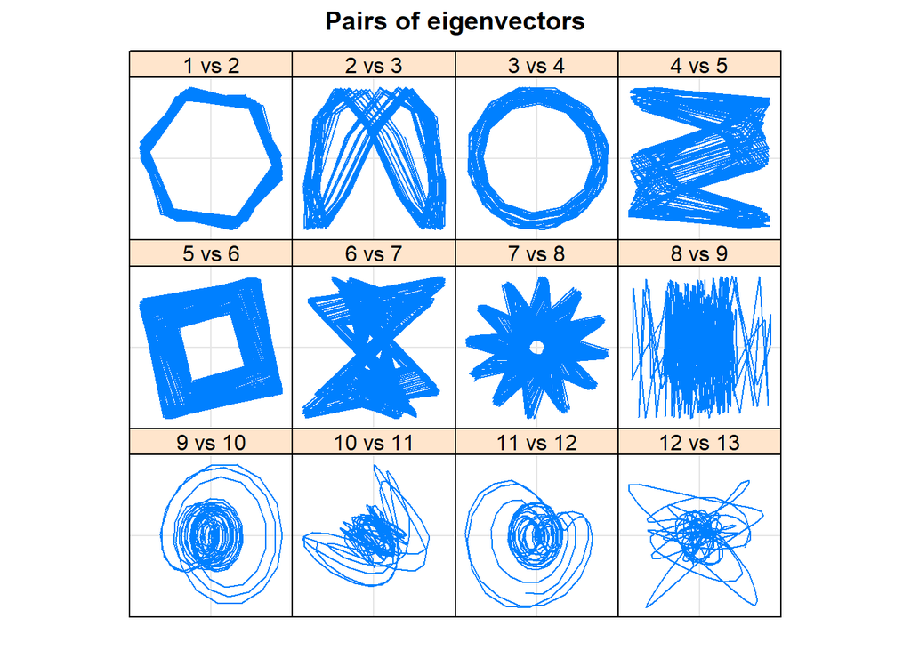

```r
plot(Women.detrend.ssa, type = "paired", idx = 1:12, plot.contrib = FALSE)
```

```r
parestimate(Women.detrend.ssa, groups = list(1:2,3:4,5:6,7:8,9:10,11:12), method = "esprit")
```

```
## $F1
##    period     rate   |    Mod     Arg  |     Re        Im
##     6.003  -0.000503 |  0.99950   1.05 |  0.50015   0.86536
##    -6.003  -0.000503 |  0.99950  -1.05 |  0.50015  -0.86536
##
## $F2
##    period     rate   |    Mod     Arg  |     Re        Im
##    12.033  -0.000421 |  0.99958   0.52 |  0.86638   0.49854
##   -12.033  -0.000421 |  0.99958  -0.52 |  0.86638  -0.49854
##
## $F3
##    period     rate   |    Mod     Arg  |     Re        Im
##     3.999  -0.001438 |  0.99856   1.57 | -0.00045   0.99856
##    -3.999  -0.001438 |  0.99856  -1.57 | -0.00045  -0.99856
##
## $F4
##    period     rate   |    Mod     Arg  |     Re        Im
##     2.399  -0.001808 |  0.99819   2.62 | -0.86496   0.49823
##    -2.399  -0.001808 |  0.99819  -2.62 | -0.86496  -0.49823
##
## $F5
##    period     rate   |    Mod     Arg  |     Re        Im
##    15.100  -0.012844 |  0.98724   0.42 |  0.90300   0.39903
##   -15.100  -0.012844 |  0.98724  -0.42 |  0.90300  -0.39903
##
## $F6
##    period     rate   |    Mod     Arg  |     Re        Im
##    19.595  -0.019228 |  0.98096   0.32 |  0.93095   0.30919
##   -19.595  -0.019228 |  0.98096  -0.32 |  0.93095  -0.30919
```

Первые 4 периодики не вызывают сомнений. Две последние и выглядят странно, и периоды у них странные.

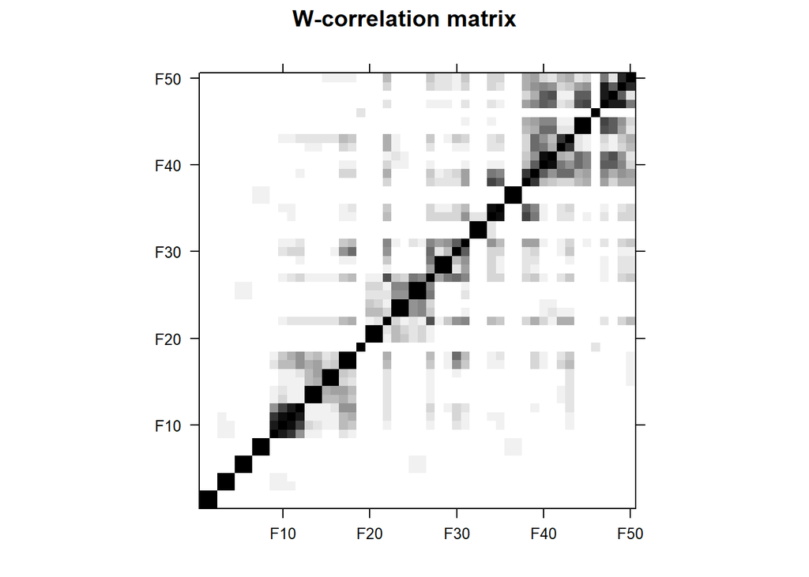

```r
plot(wcor(Women.detrend.ssa, groups = 1:50),
          scales = list(at = c(10, 20, 30,40,50)))
```

Также отчетливо выделяются 4 периодики. Но нам этого не достаточно. Сначала попробуем выведать все, что можно, из матрицы взвешенных корреляций. На ней можно заметить квадратики, особо не коррелирующие с остальными, но имеющие уже не очень большой вклад. Это пары 32-33 и 36-37. Также выделяется 19 и 46 компонента, они не коррелируют с остальными (только немного между собой).

Возможно, компоненты 19 и 46 – это две пилы. Посмотрим, как они выглядят:

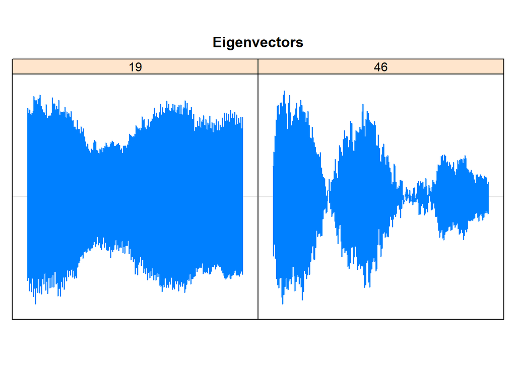

```r
plot(Women.detrend.ssa, type = "vectors", idx = c(19,46), plot.contrib = FALSE)
```

Удостоверимся:

```r
parestimate(Women.detrend.ssa, groups = list(19,46), method = "esprit")
```

```
## $F1
##    period     rate   |    Mod     Arg  |     Re        Im
##     2.000  -0.003630 |  0.99638   3.14 | -0.99638   0.00000
##
## $F2
##    period     rate   |    Mod     Arg  |     Re        Im
##     2.000  -0.018527 |  0.98164   3.14 | -0.98164   0.00000
```

19 похожа на пилу, а 46 смесь чего-то (имеет сильную модуляцию).

Проверим теперь пары 32-33 и 36-37.

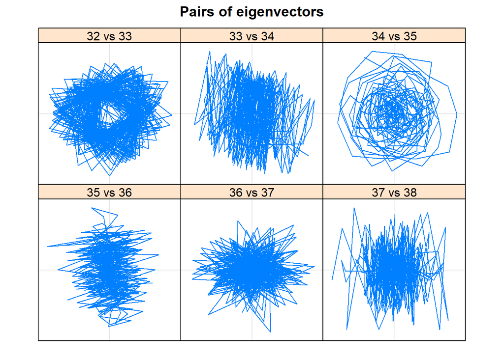

```r
plot(Women.detrend.ssa, type = "paired", idx = 32:37, plot.contrib = FALSE)
```

```r
parestimate(Women.detrend.ssa, groups = list(32:33,36:37), method = "esprit")
```

```
## $F1
##    period     rate   |    Mod     Arg  |     Re        Im
##     3.066  -0.044602 |  0.95638   2.05 | -0.44015   0.84907
##    -3.066  -0.044602 |  0.95638  -2.05 | -0.44015  -0.84907
##
## $F2
##    period     rate   |    Mod     Arg  |     Re        Im
##     2.415  -0.041079 |  0.95975   2.60 | -0.82323   0.49338
##    -2.415  -0.041079 |  0.95975  -2.60 | -0.82323  -0.49338
```

Периоды этих парочек выглядят правдоподобно: 3 и 2.4. Такие периоды для нас актуальны.

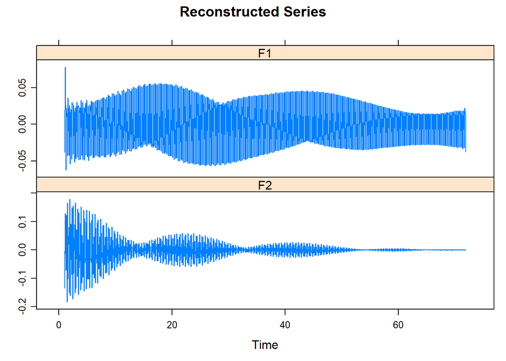

```r
plot(reconstruct(Women.detrend.ssa, groups = list(32:33,36:37)),
     plot.method = "xyplot", layout = c(1,2),
     add.residuals = FALSE, add.original = FALSE)
```

Берем все рассмотренные компоненты в сезонность (они описывают периоды 6,12, 4, 2.4, 3, 2):

```r
Women.detrend.reconstruct <- reconstruct(Women.detrend.ssa,
                      groups = list(Seasonality = c(1:8,19,46,32:33,36:37)))
```

Периодограмма остатка:

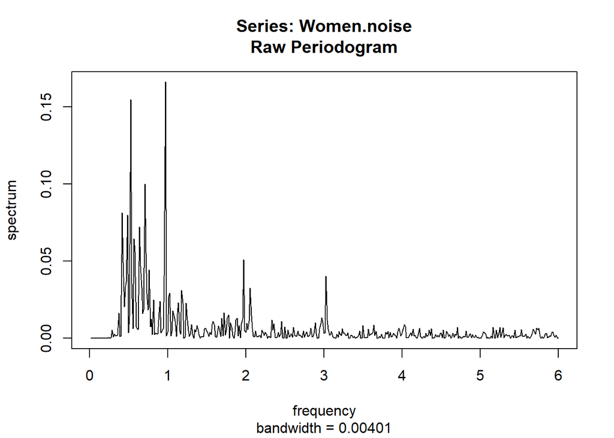

```r
Women.noise<-ts(Women.detrend-Women.detrend.reconstruct$Seasonality,frequency = 12)
spec.pgram(Women.noise, log="no")
```

Все еще остались периоды 12, 6 и 4.

Снова посмотрим на матрицу взвешенных корреляций:

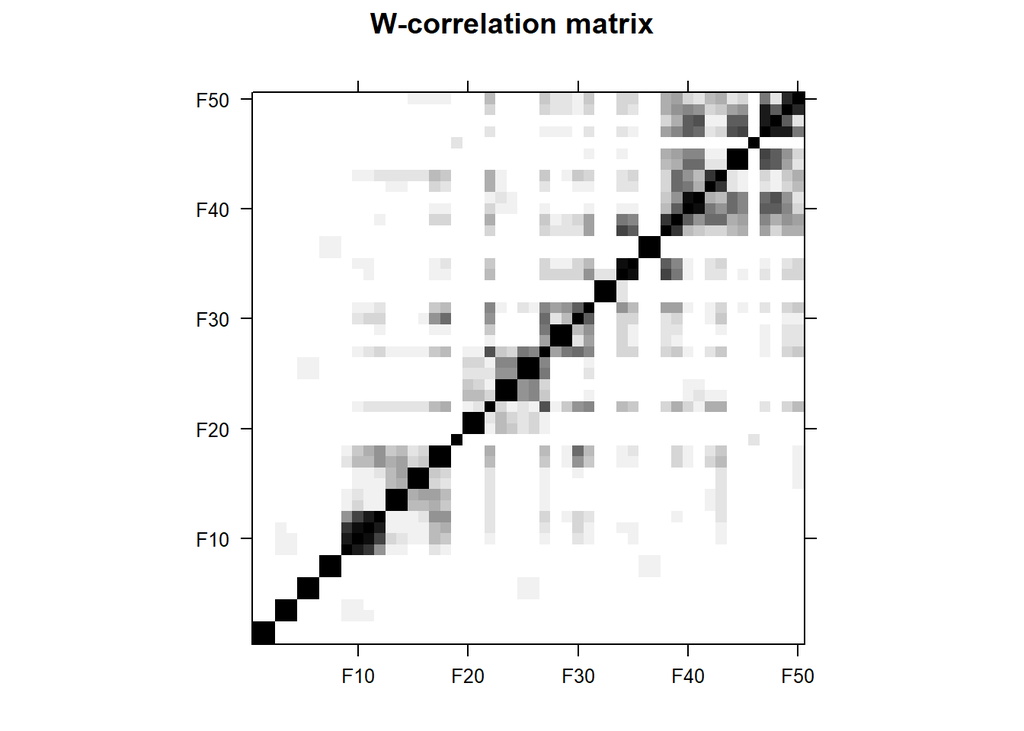

```r
plot(wcor(Women.detrend.ssa, groups = 1:50),
          scales = list(at = c(10, 20, 30,40,50)))
```

Заметим, что компоненты 20-21,23-24,25-26 образуют блок компонент, которые коррелируют между собой, но не коррелируют с другими.

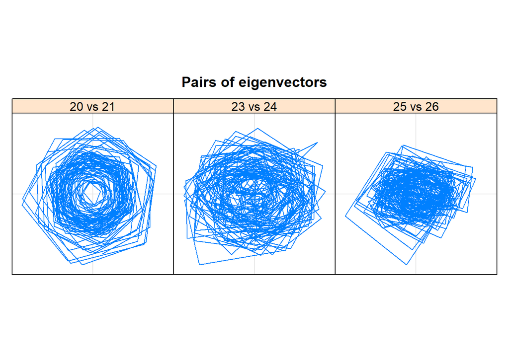

```r
plot(Women.detrend.ssa, type = "paired", idx = c(20,23,25), idy = c(21,24,26), plot.contrib = FALSE)
```

```r
parestimate(Women.detrend.ssa, groups = list(20:21,23:24,25:26), method = "esprit")
```

```
## $F1
##    period     rate   |    Mod     Arg  |     Re        Im
##     6.033  -0.015663 |  0.98446   1.04 |  0.49708   0.84975
##    -6.033  -0.015663 |  0.98446  -1.04 |  0.49708  -0.84975
##
## $F2
##    period     rate   |    Mod     Arg  |     Re        Im
##     6.002  -0.140996 |  0.86849   1.05 |  0.43449   0.75200
##    -6.002  -0.140996 |  0.86849  -1.05 |  0.43449  -0.75200
##
## $F3
##    period     rate   |    Mod     Arg  |     Re        Im
##     4.733  -0.236549 |  0.78935   1.33 |  0.19004   0.76613
##    -4.733  -0.236549 |  0.78935  -1.33 |  0.19004  -0.76613
```

Похоже, что пары 20-21 и 23-24 – это перемешавшиеся периодики с периодом 6. Пара 25-26 имеет неправдоподобный период 4.7, но при этом очень сильно коррелирует с парой 23-24. Это странно. В итоге эта пара перебивает период 4, так что ее тоже нужно брать. (возможно, при помощи iossa это тоже получится подкрутить).

Другой блок (9:18) не похож на перемешавшиеся периодики, тк коррелирует и с остальными. Однако мы до сих пор не нашли недостающую гармонику с периодом 12. Проверим периоды на всякий случай:

```r
parestimate(Women.detrend.ssa, groups = list(9:10,11:12,13:14,15:16,17:18), method = "esprit")
```

```
## $F1
##    period     rate   |    Mod     Arg  |     Re        Im
##    15.100  -0.012844 |  0.98724   0.42 |  0.90300   0.39903
##   -15.100  -0.012844 |  0.98724  -0.42 |  0.90300  -0.39903
##
## $F2
##    period     rate   |    Mod     Arg  |     Re        Im
##    19.595  -0.019228 |  0.98096   0.32 |  0.93095   0.30919
##   -19.595  -0.019228 |  0.98096  -0.32 |  0.93095  -0.30919
##
## $F3
##    period     rate   |    Mod     Arg  |     Re        Im
##    17.935  -0.005452 |  0.99456   0.35 |  0.93415   0.34134
##   -17.935  -0.005452 |  0.99456  -0.35 |  0.93415  -0.34134
##
## $F4
##    period     rate   |    Mod     Arg  |     Re        Im
##    19.511  -0.001420 |  0.99858   0.32 |  0.94725   0.31604
##   -19.511  -0.001420 |  0.99858  -0.32 |  0.94725  -0.31604
##
## $F5
##    period     rate   |    Mod     Arg  |     Re        Im
##    21.931  -0.011408 |  0.98866   0.29 |  0.94836   0.27939
##   -21.931  -0.011408 |  0.98866  -0.29 |  0.94836  -0.27939
```

Пара 9:10 имеет период примерно 15. Однако, так как ближе к 12ти ничего другого нет, пробуем ее добавить и, о чудо, эта пара справляется с периодом 12. (так, видимо, тоже получилось из-за того, что гармоники перемешались)

Обновим результат.

```r
Women.detrend.reconstruct <- reconstruct(Women.detrend.ssa,
                      groups = list(Seasonality = c(1:8,9:10,19,20:21,23:24,25:26,32:33,36:37)))
```

Периодограмма шума:

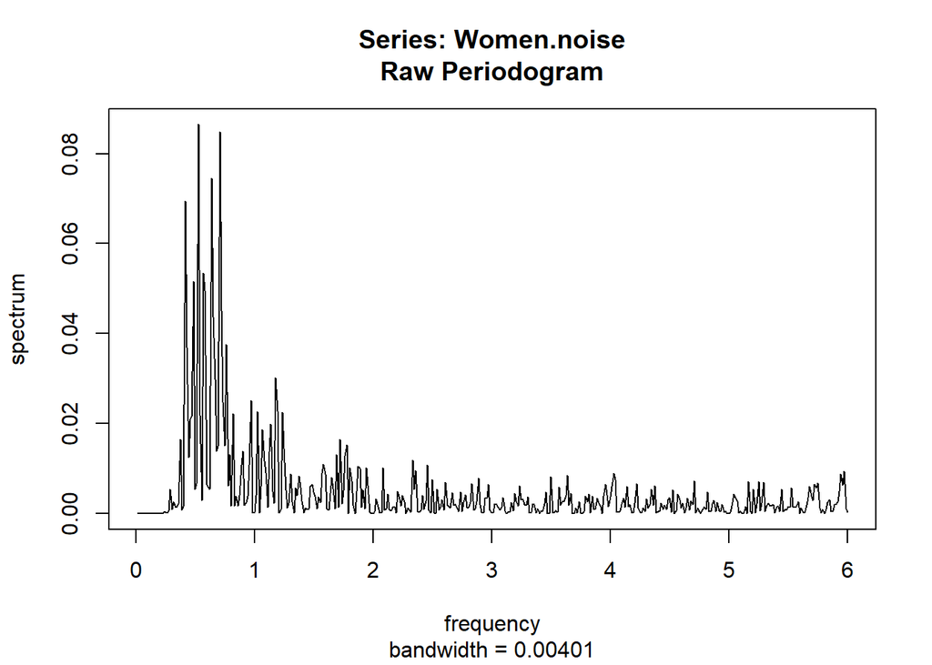

```r
Women.noise<-ts(Women.detrend-Women.detrend.reconstruct$Seasonality,frequency = 12)
spec.pgram(Women.noise, log="no")
```

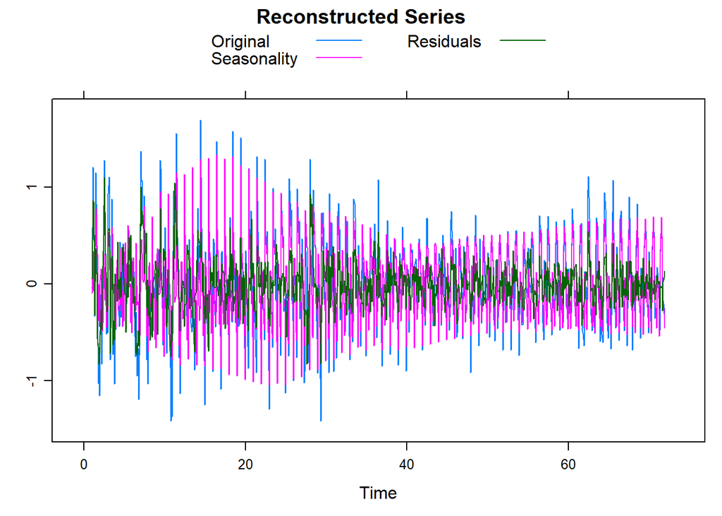

```r
plot(Women.detrend.reconstruct , add.residuals = TRUE, add.original = TRUE,
     plot.method = "xyplot",
     superpose = TRUE, auto.key = list(columns = 2))
```

# 3 Автоматическая идентификация

Посмотрим, какие результаты дает автоматическая группировка.

Для тренда. Частотная группировка:

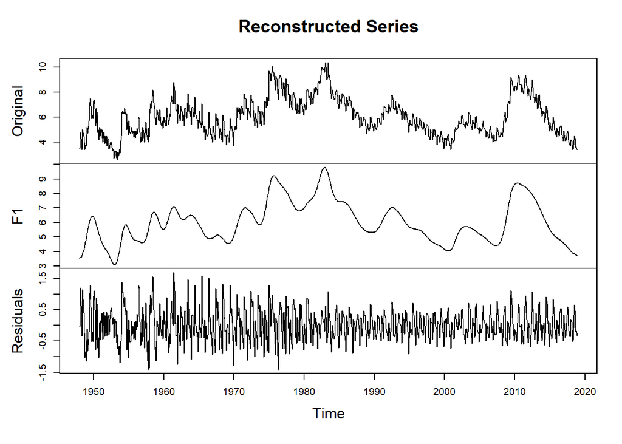

```r
gr1 <- grouping.auto(trend.SSA, grouping.method = "pgram", groups = 1:20, base = "series",freq.bins = list(1/24), threshold = 0.95)
plot(reconstruct(trend.SSA, groups = gr1))
```

```r
head(gr1)
```

```
## $F1
## [1] 1 2 3
```

Автоматическая группировка взяла первые 3 компоненты разложения в тренд. Мы поступили так же.

Кластерная группировка для ряда без тренда. Возьмем сначала в качестве компонент, из которых выбирать, с 1 по 37 компоненту. (последняя взятая нами вручную компонента – 37, но внутри брали не все)

```r
gr <- grouping.auto(Women.detrend.ssa, grouping.method = "wcor", groups=1:37)
head(gr,50)
```

```
## $`1`
## [1] 1 2
##
## $`2`
## [1] 3 4
##
## $`3`
## [1] 5 6
##
## $`4`
## [1] 7 8
##
## $`5`
## [1]  9 10 11
##
## $`6`
## [1] 12 17 18
##
## $`7`
## [1] 13 14
##
## $`8`
## [1] 15 16
##
## $`9`
## [1] 19
##
## $`10`
## [1] 20 21
##
## $`11`
## [1] 22 27
##
## $`12`
## [1] 23 24
##
## $`13`
## [1] 25 26
##
## $`14`
## [1] 28 29
##
## $`15`
## [1] 30 31
##
## $`16`
## [1] 32 33
##
## $`17`
## [1] 34 35
##
## $`18`
## [1] 36 37
```

Метод выделил 18 кластеров (мы – 11). Также выделил одинокую пилу и большинство групп (только их здесь больше). Ну и в целом на данный момент это просто распаривание всего подряд.

Если теперь укажем желаемое количество кластеров (+1 для шума, чтобы чисто теоретически метод мог разделить так же, как мы):

```r
gr <- grouping.auto(Women.detrend.ssa, grouping.method = "wcor", groups=1:37,nclust=12)
head(gr,50)
```

```
## $`1`
## [1] 1 2
##
## $`2`
## [1] 3 4
##
## $`3`
## [1] 5 6
##
## $`4`
## [1] 7 8
##
## $`5`
## [1]  9 10 11
##
## $`6`
## [1] 12 13 14 15 16 17 18
##
## $`7`
## [1] 19
##
## $`8`
## [1] 20 21 23 24 25 26
##
## $`9`
## [1] 22 27 30 31 34 35
##
## $`10`
## [1] 28 29
##
## $`11`
## [1] 32 33
##
## $`12`
## [1] 36 37
```

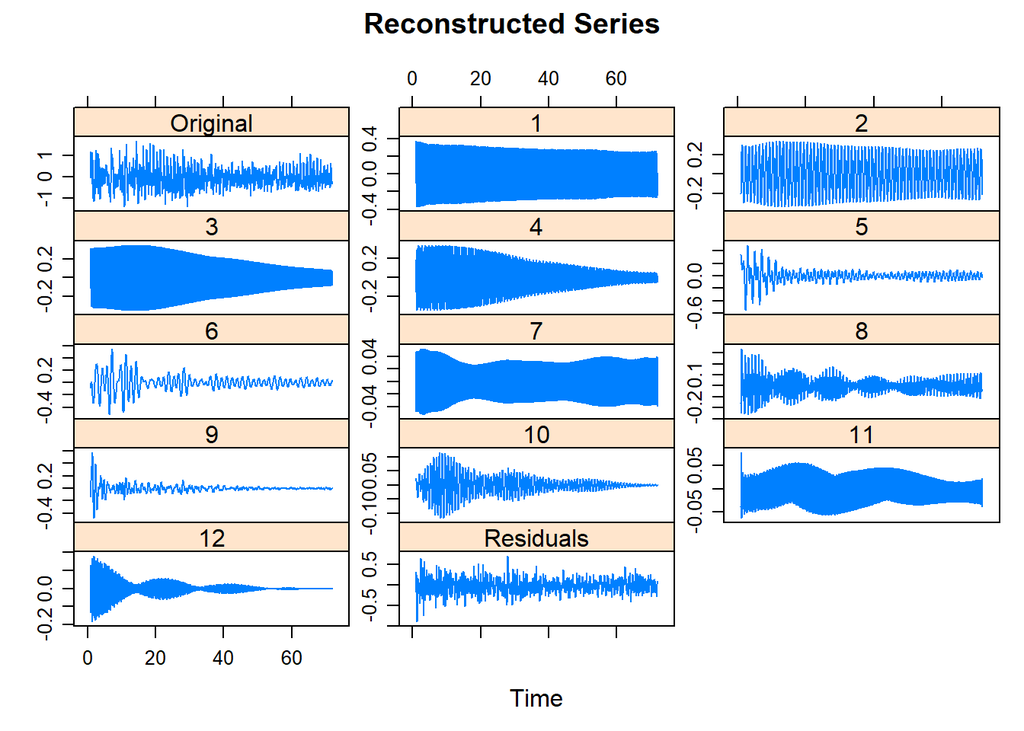

```r
plot(reconstruct(Women.detrend.ssa, groups = gr),plot.method = "xyplot")
```

Наиболее очевидные вещи метод заметил. Он попарно выделил первые 4 периодики (которые мы выделили первым делом), 19 (пила) – выделил отдельно, компоненты 20,21,23,24,25,26, которые есть смешавшиеся периодики, – выделил в одну группу, но не разделил попарно (это и не удивительно). Выделил периодики 32:33, 36:37.

Если считать, что если в кластере больше 2х компонент, то кластер соответствует шуму, то можно сказать, что в шум отправились компоненты 12:18, 22, 27, 30, 31, 34, 35, блок периодик 20,21,23:26 и 9,10,11 (мы брали пару 9:10, но она тоже совсем не очевидная).

Понятно, что такой подход не способен выделить весь шум в одну компоненту в данном случае, так как сигнал в матрице взвешенных корреляций у нас разбросан (то есть не так, что сигнал в начале, а шум в конце, все вперемешку). (Поэтому если просить метод выдать 2 кластера: сезонность и шум, то совсем ерунда получается.)

Попробуем увеличть количество кластеров, вдруг еще что хорошее разделится.

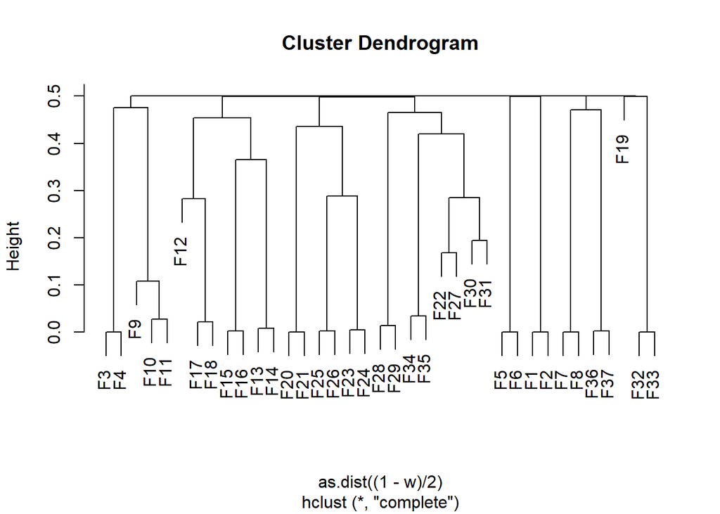

```r
gr <- grouping.auto(Women.detrend.ssa, grouping.method = "wcor", groups=1:37,nclust=15)
plot(gr)
```

```r
head(gr,50)
```

```
## $`1`
## [1] 1 2
##
## $`2`
## [1] 3 4
##
## $`3`
## [1] 5 6
##
## $`4`
## [1] 7 8
##
## $`5`
## [1]  9 10 11
##
## $`6`
## [1] 12 17 18
##
## $`7`
## [1] 13 14 15 16
##
## $`8`
## [1] 19
##
## $`9`
## [1] 20 21
##
## $`10`
## [1] 22 27 30 31
##
## $`11`
## [1] 23 24 25 26
##
## $`12`
## [1] 28 29
##
## $`13`
## [1] 32 33
##
## $`14`
## [1] 34 35
##
## $`15`
## [1] 36 37
```

Разделился скорее шум на несколько кластеров, чем периодики друг от друга. И в нашем случае результат этой автоматической группировки почти невозможно адекватно интерпретировать. Разбито на пары, но совершенно не ясно, какие пары шум, а какие – нет (раз в нашем случае нельзя сказать, что все, что по номеру больше – шум).

# 4 Улучшение разделимости

Итак, выделили сезонность. Попробуем подкрутить, чтобы гармоники лучше разделились. Удобнее снова смотреть на матрицу взвешенных корреляций (только сезонности).

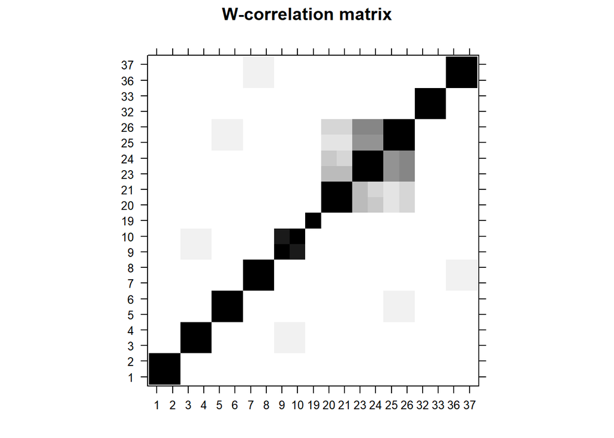

```r
plot(wcor(Women.detrend.ssa, groups = c(1:8,9:10,19,20:21,23:24,25:26,32:33,36:37)),
     scales = list(at = c(1:21),labels=c(1:8,9:10,19,20:21,23:24,25:26,32:33,36:37)))
```

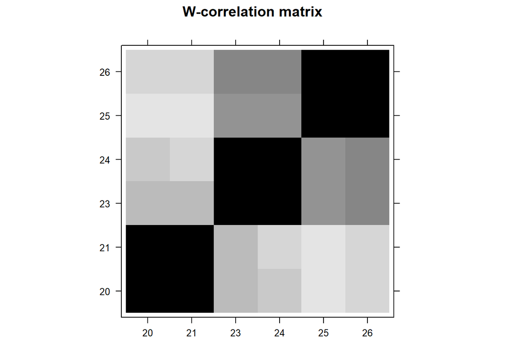

```r
plot(wcor(Women.detrend.ssa, groups = c(20:21,23:24,25:26)),
     scales = list(at = c(1:6),labels=c(20:21,23:24,25:26)))
```

Подозреваем, что 20-21,23-24,25-26 – три смешавшиеся гармоники. Проблема с сильной разделимостью, собственные числа у них почти равны. Запускаем почти для всего сигнала, так как по-отдельности хуже получается.

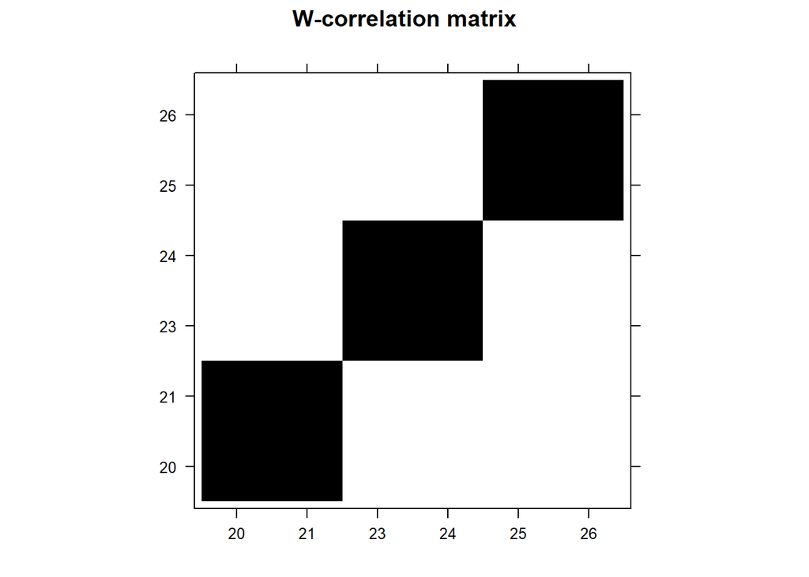

```r
Wiossa<-iossa(Women.detrend.ssa, nested.groups = list(3:4,5:6,7:8,9:10,20:21,23:24,25:26,36:37))
plot(owcor(Wiossa, groups = c(20:21,23:24,25:26)),
     scales = list(at = c(1:6),labels=c(20:21,23:24,25:26)))
```

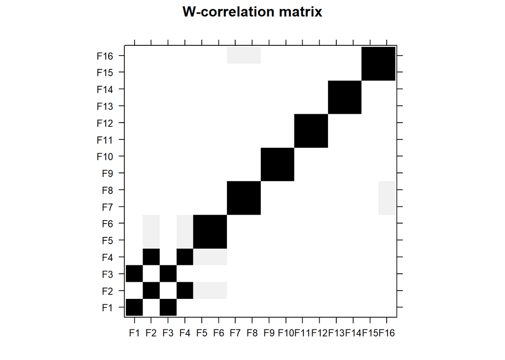

```r
plot(owcor(Wiossa, groups =list(3,4,5,6,7,8,9,10,20,21,23,24,25,26,36,37),
          scales = list(at = c(1:16),labels=list(3,4,5,6,7,8,9,10,20,21,23,24,25,26,36,37))))
```

Посмотрим, как изменились обычные взвешенные корреляции:

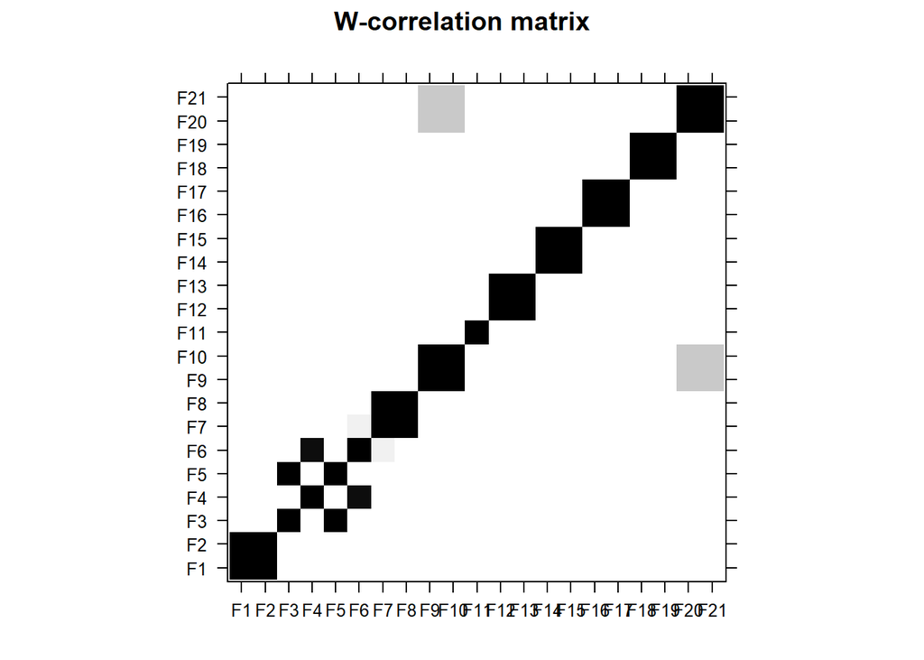

```r
plot(wcor(Wiossa, groups = c(1:8,9:10,19,20:21,23:24,25:26,32:33,36:37),
          scales = list(at = c(1:21),labels=c(1:8,9:10,19,20:21,23:24,25:26,32:33,36:37))))
```

Некоторые компоненты поменялись местами. Матрица взвешенных корреляций почистилась, но закоррелировались компоненты 9:10 и 36:37.

# 5 Корни характеристического многочлена

## 5.1 Моделированный ряд

Рассмотрим ряд $x_{n}=0.4e^{n/100}+3cos(2\pi*1/2*n)+e^{n/100}cos(2\pi*4/12*n)+2ncos(2*\pi*1/6*n)$.

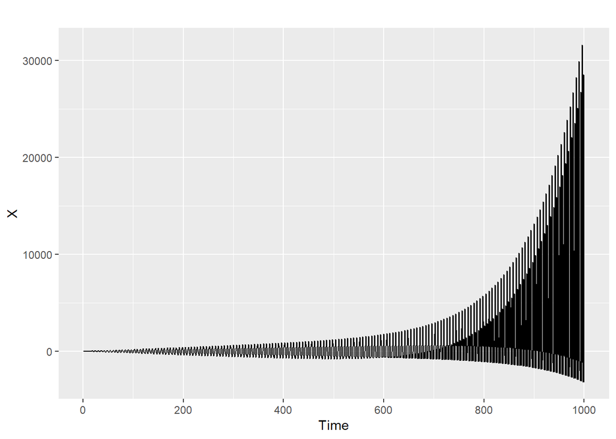

```r
N<-1:1000
X<-ts(0.4*exp(N/100)+3*cos(2*pi*1/2*N)+exp(N/100)*cos(2*pi*4/12*N)+2*N*cos(2*pi*1/6*N))
autoplot(X)
```

Ранг ряда равен 8 (1+1+2+4). По порядку. Корень характеристического многочлена первого слагаемого равен $e^{1/100}\approx 1.01005$, т.е. почти единица, будет на вещественной оси чуть правее едничной окружности. Второее слагаемое ранга 1 (частота косинуса = 1/2), это будет вещественный корень (-1). Третье слагаемое – экспоненциально модулированный косинус, имеет ранг 2 и два сопряженных корня, чуть вылезающие за единичную окружность (угол $2\pi/3$). Ранг четвертого слагаемого равен 4. Предполагаем, что это будет пара сопряженных комплексных корней кратности 2 (линейная функция дает кратность).

```r
d<-8
X.ssa<-ssa(X,L=(d+1))
l <- lrr(X.ssa,groups = list(1:d))
r <- roots(l)
Mod(r)
```

```
## [1] 1.0100502 1.0100502 1.0100502 1.0000007 1.0000007 1.0000000 0.9999993
## [8] 0.9999993
```

```r
Arg(r)
```

```
## [1]  2.094395 -2.094395  0.000000  1.047198 -1.047198  3.141593  1.047197
## [8] -1.047197
```

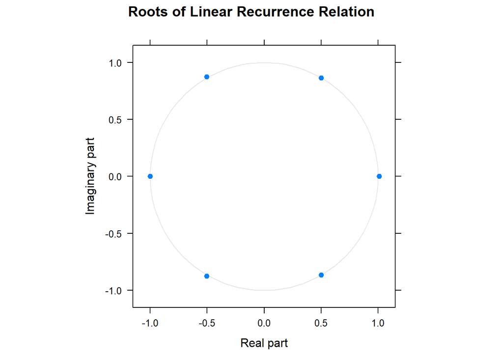

```r
plot(l)
```

Корни 4го слагаемого очень близки друг к другу. Остальное все тоже совпадает с предположениями.

Чтобы попугаться, сделаем то же самое для большой длины окна (L=500) и нарисуем все корни lrr (их будет 499).

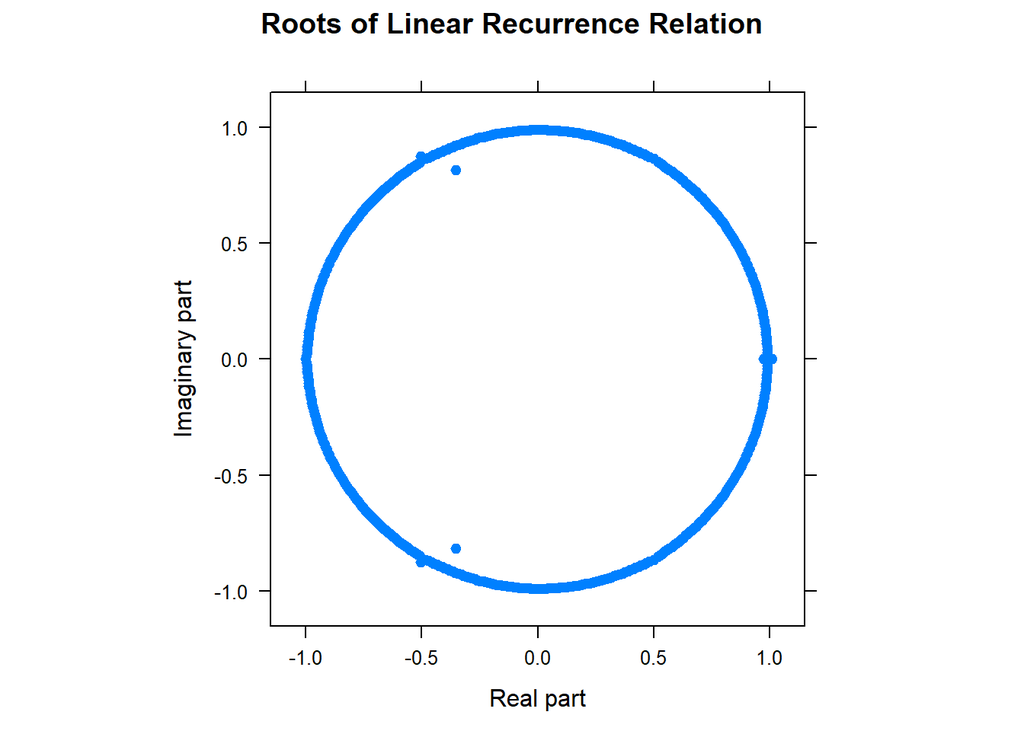

```r
d<-8
X.ssa<-ssa(X,L=(500))
l <- lrr(X.ssa,groups = list(1:d))
r <- roots(l)
plot(l)
```

Сравним с тем, что выдает esprit. Возьмем $L=500$.

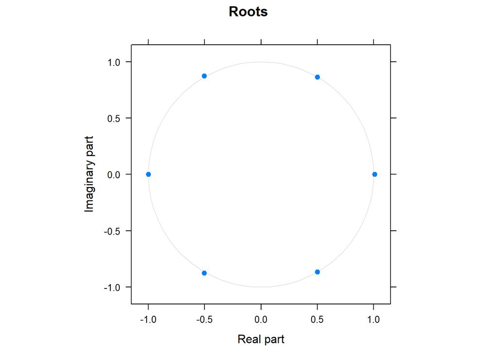

```r
X.ssa<-ssa(X,L=500)
par<-parestimate(X.ssa, groups=list(1:d), method = 'esprit')
plot(par)
```

```r
print(par)
```

```
##    period     rate   |    Mod     Arg  |     Re        Im
##     3.000   0.010000 |  1.01005   2.09 | -0.50503   0.87473
##    -3.000   0.010000 |  1.01005  -2.09 | -0.50503  -0.87473
##       Inf   0.010000 |  1.01005   0.00 |  1.01005   0.00000
##     6.000   0.000000 |  1.00000   1.05 |  0.50000   0.86603
##    -6.000   0.000000 |  1.00000  -1.05 |  0.50000  -0.86603
##     2.000   0.000000 |  1.00000   3.14 | -1.00000   0.00000
##     6.000  -0.000000 |  1.00000   1.05 |  0.50000   0.86603
##    -6.000  -0.000000 |  1.00000  -1.05 |  0.50000  -0.86603
```

Вроде все так.

Тут (для удобства выпишем)“”

1,2 – $e^{n/100}cos(2\pi*4/12*n)$,

3 – $e^{n/100}$,

4,5,7,8 – $2ncos(2*\pi*1/6*n)$,

6 – $cos(2\pi*1/2*n)=(-1)^{n}$.

Решаем систему линейных уравнений.

```r
mu<-par$roots
W<-t(matrix(mu,nrow = d,ncol = d))^(1:d)
W[,7]<-W[,4]*(1:d)
W[,8]<-W[,5]*(1:d)
C<-solve(W,X[1:d])
print(C)
```

```
## [1] 5.00000e-01+0.000000e+00i 5.00000e-01-0.000000e+00i
## [3] 4.00000e-01+0.000000e+00i 3.05030e-09-3.561420e-08i
## [5] 3.02482e-09+3.516132e-08i 3.00000e+00-0.000000e+00i
## [7] 1.00000e+00+0.000000e+00i 1.00000e+00-0.000000e+00i
```

Это коэффициенты для формулы в комплексной форме. Мы генерировали через вещественную, так что и сравнивать удобнее в ней (получим далее).

Сгенерируем полученный ряд и сравним с исходным внешне:

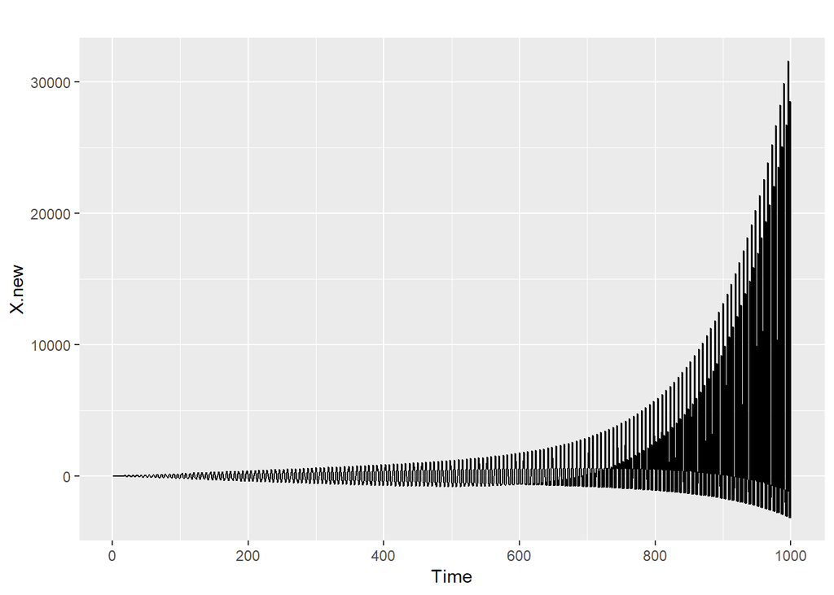

```r
W.full<-t(matrix(mu,nrow = d,ncol = length(N)))^N
W.full[,7]<-W.full[,4]*(1:length(N))
W.full[,8]<-W.full[,5]*(1:length(N))
X.new<-ts(W.full%*%C)
autoplot(X.new)
```

Да, очень похоже.

Попробуем сразу получать вещественные коэффициенты.

```r
rank<-8
len<-rank
#len<-length(N)
mu<-par$roots
mu.moduli<-par$moduli
mu.periods<-par$periods
W<-matrix(nrow = len,ncol = d)
for (i in 1:rank) {
  if (mu.periods[i] == Inf)
    W[, i] <- mu.moduli[i]^(1:len)
  else if (mu.periods[i] == 2)
    W[, i] <- (-mu.moduli[i])^(1:len)
  else if (mu.periods[i] > 0)
    W[, i] <-
      mu.moduli[i]^(1:len) * sin(2 * pi * (1:len) / mu.periods[i])
  else
    W[, i] <-
      mu.moduli[i]^(1:len) * cos(2 * pi * (1:len) / mu.periods[i])
}
W[,7]<-W[,4]*(1:len)
W[,8]<-W[,5]*(1:len)
C<-solve(W,X[1:len])
print(round(C,digits = 4))
```

```
## [1] 0.0 1.0 0.4 0.0 0.0 3.0 0.0 2.0
```

Тогда коэффициенты совпадают с тем, как мы генерировали ряд.

Добавим к сигналу шум:

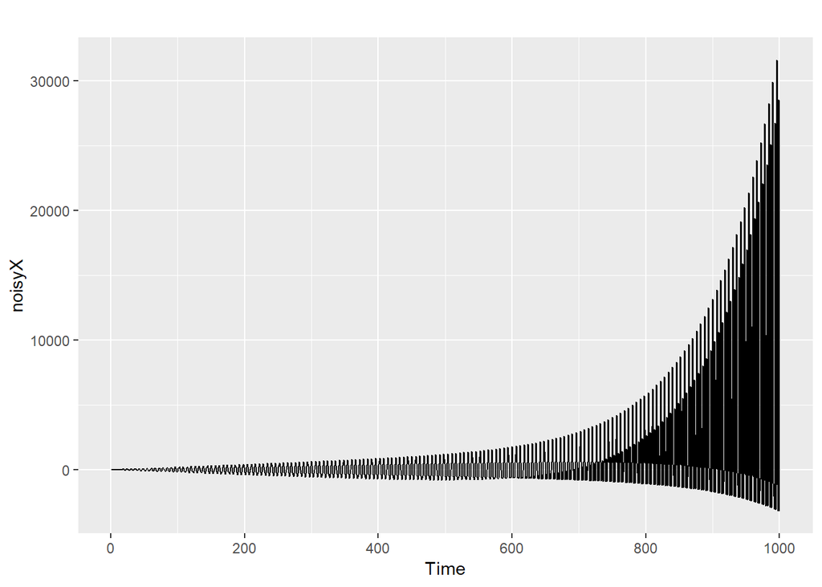

```r
noisyX<-X+rnorm(length(X),0,1)
autoplot(noisyX)
```

Находим корни:

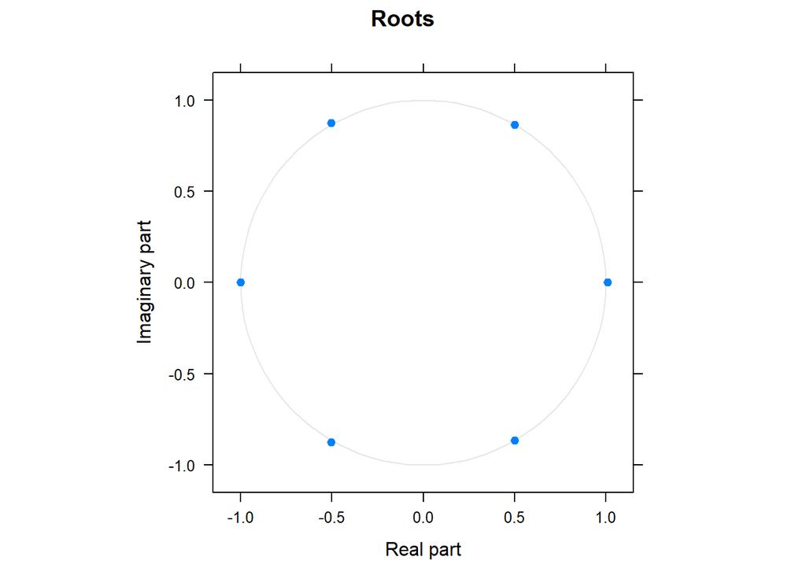

```r
d<-8
noisyX.ssa<-ssa(noisyX,L=500)
npar<-parestimate(noisyX.ssa, groups=list(1:d), method = 'esprit')
plot(npar)
```

```r
print(npar)
```

```
##    period     rate   |    Mod     Arg  |     Re        Im
##       Inf   0.010000 |  1.01005  -0.00 |  1.01005  -0.00000
##     3.000   0.009999 |  1.01005   2.09 | -0.50502   0.87473
##    -3.000   0.009999 |  1.01005  -2.09 | -0.50502  -0.87473
##     6.000   0.000088 |  1.00009   1.05 |  0.50007   0.86608
##    -6.000   0.000088 |  1.00009  -1.05 |  0.50007  -0.86608
##     2.000  -0.000026 |  0.99997   3.14 | -0.99997   0.00000
##     6.000  -0.000091 |  0.99991   1.05 |  0.49992   0.86596
##    -6.000  -0.000091 |  0.99991  -1.05 |  0.49992  -0.86596
```

Получили примерно то же, что и раньше.

Находим коэффициенты. Сразу воспользуемся вещественной формой. (Корни, соответствующие последнему слагаемому считаем кратными.)

```r
rank<-8
len<-length(N)
mu<-par$roots
mu.moduli<-par$moduli
mu.periods<-par$periods
W.full<-matrix(nrow = len,ncol = rank)
for (i in 1:rank) {
  if (mu.periods[i] == Inf)
    W.full[, i] <- mu.moduli[i]^(1:len)
  else if (mu.periods[i] == 2)
    W.full[, i] <- (-mu.moduli[i])^(1:len)
  else if (mu.periods[i] > 0)
    W.full[, i] <-
      mu.moduli[i]^(1:len) * sin(2 * pi * (1:len) / mu.periods[i])
  else
    W.full[, i] <-
      mu.moduli[i]^(1:len) * cos(2 * pi * (1:len) / mu.periods[i])
}
W.full[,7]<-W.full[,4]*(1:length(N))
W.full[,8]<-W.full[,5]*(1:length(N))
noisyC<-ginv(W.full)%*%noisyX
print(round(noisyC,digits = 4))
```

```
##         [,1]
## [1,]  0.0000
## [2,]  1.0000
## [3,]  0.4000
## [4,] -0.0389
## [5,]  0.0120
## [6,]  3.0269
## [7,]  0.0000
## [8,]  2.0000
```

```r
print(round(C,digits = 4))
```

```
## [1] 0.0 1.0 0.4 0.0 0.0 3.0 0.0 2.0
```

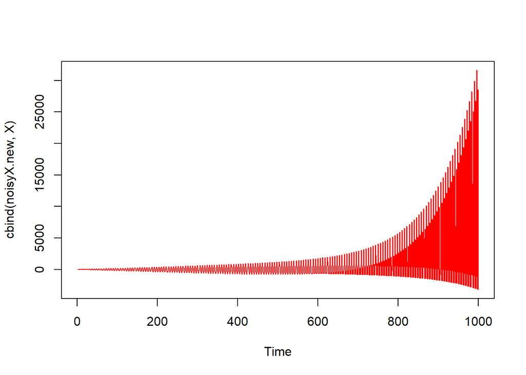

```r
noisyX.new<-ts(W.full%*%noisyC)
plot.ts(cbind(noisyX.new,X), plot.type = 'single', col = c('black', 'red'))
```

Ну, вроде все хорошо, но у нас и шум был очень простой.

## 5.2 Реальный ряд

Пробуем с нашим рядом.

Будем проделывать это для сезонности. (Пробовала сделать для всего ряда, но там выходит очень уж громоздко: чтобы как-то побороть периодичность в шуме, пришлось взять очень много компонент (50) и такое ощущение, что в итоге очен много шума прихватили в сигнал).

```r
Women.detrend.ssa<-Wiossa
Women.detrend.reconstruct <- reconstruct(Women.detrend.ssa,
                      groups = list(Seasonality = c(1:8,9:10, 19,20:21,23:24,25:26,32:33,36:37)))
```

Выделенная сезонность:

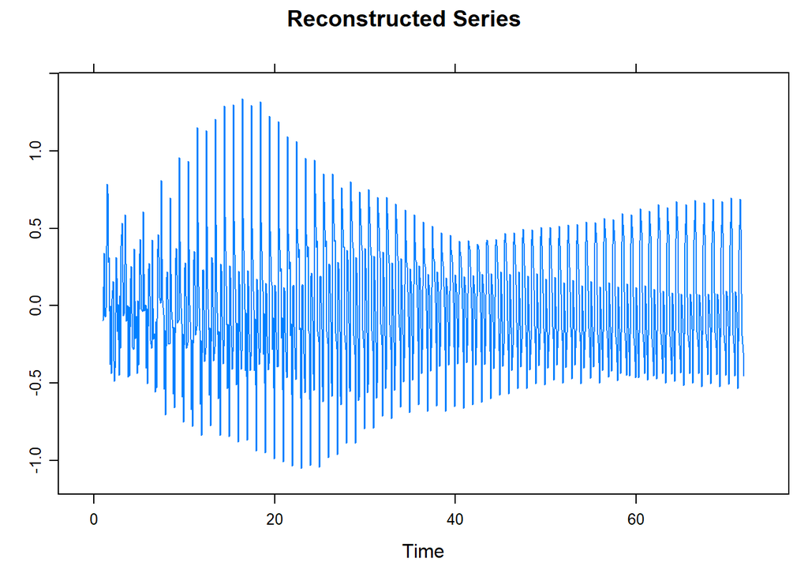

```r
plot(Women.detrend.reconstruct , add.residuals = FALSE, add.original = FALSE,
     plot.method = "xyplot",
     superpose = TRUE)
```

По числу взятых в сезонность компонент считаем, что ранг сезонной компоненты равен 21.

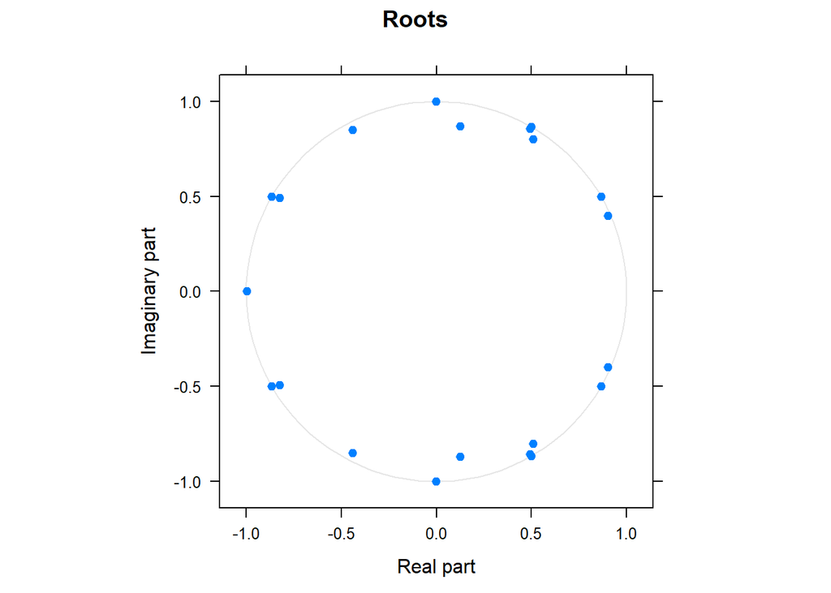

```r
d<-21
Wpar<-parestimate(Women.detrend.ssa, groups=list(c(1:8,9:10, 19,20:21,23:24,25:26,32:33,36:37)), method = 'esprit')
plot(Wpar)
```

На рисунке видим, что тренда нет, видим пилу и модулированные периодики соответствующих порядков. Заметим, что многие из них есть пара или даже тройка близлежащих сопряженных корней. Понятно, что в реальном случае мы не могли получить кратные корни, как в моделированном примере, но такие близкие корни могут означать, что истинная модуляция не экспоненциальная, а имеет более сложную форму. Получается, что такая модуляция будет как бы аппроксимироваться суммой близких экспонентально моделированных гармоник.

```r
print(Wpar)
```

```
##    period     rate   |    Mod     Arg  |     Re        Im
##    12.034  -0.000182 |  0.99982   0.52 |  0.86661   0.49862
##   -12.034  -0.000182 |  0.99982  -0.52 |  0.86661  -0.49862
##     6.001  -0.000582 |  0.99942   1.05 |  0.49981   0.86546
##    -6.001  -0.000582 |  0.99942  -1.05 |  0.49981  -0.86546
##     3.999  -0.001384 |  0.99862   1.57 | -0.00057   0.99862
##    -3.999  -0.001384 |  0.99862  -1.57 | -0.00057  -0.99862
##     2.399  -0.001946 |  0.99806   2.62 | -0.86489   0.49808
##    -2.399  -0.001946 |  0.99806  -2.62 | -0.86489  -0.49808
##     2.000  -0.002106 |  0.99790   3.14 | -0.99790   0.00000
##    15.101  -0.012831 |  0.98725   0.42 |  0.90302   0.39902
##   -15.101  -0.012831 |  0.98725  -0.42 |  0.90302  -0.39902
##     5.988  -0.013255 |  0.98683   1.05 |  0.49162   0.85565
##    -5.988  -0.013255 |  0.98683  -1.05 |  0.49162  -0.85565
##     2.414  -0.039195 |  0.96156   2.60 | -0.82514   0.49371
##    -2.414  -0.039195 |  0.96156  -2.60 | -0.82514  -0.49371
##     3.069  -0.043370 |  0.95756   2.05 | -0.43894   0.85103
##    -3.069  -0.043370 |  0.95756  -2.05 | -0.43894  -0.85103
##     6.248  -0.052756 |  0.94861   1.01 |  0.50801   0.80112
##    -6.248  -0.052756 |  0.94861  -1.01 |  0.50801  -0.80112
##     4.396  -0.130980 |  0.87724   1.43 |  0.12385   0.86845
##    -4.396  -0.130980 |  0.87724  -1.43 |  0.12385  -0.86845
```

Находим коэффициенты:

```r
mu<-Wpar$roots
N<-1:length(Women.detrend)
W.full<-t(matrix(mu,nrow = d,ncol = length(N)))^N
C<-ginv(W.full)%*%Women.detrend
print(C)
```

```
##                          [,1]
##  [1,] -0.15398222-0.03873846i
##  [2,] -0.15398222+0.03873846i
##  [3,]  0.02666346-0.21901948i
##  [4,]  0.02666346+0.21901948i
##  [5,] -0.17871227+0.05164097i
##  [6,] -0.17871227-0.05164097i
##  [7,] -0.18881805+0.08702148i
##  [8,] -0.18881805-0.08702148i
##  [9,] -0.07113974+0.00000000i
## [10,] -0.00774397-0.10809445i
## [11,] -0.00774397+0.10809445i
## [12,]  0.12253905+0.13196577i
## [13,]  0.12253905-0.13196577i
## [14,]  0.15784156+0.07658942i
## [15,]  0.15784156-0.07658942i
## [16,] -0.01008753+0.02910608i
## [17,] -0.01008753-0.02910608i
## [18,] -0.00685809-0.30980695i
## [19,] -0.00685809+0.30980695i
## [20,]  0.04361390+0.39270277i
## [21,]  0.04361390-0.39270277i
```

По полученной комплексной формуле генерируем ряд и сравниваем его с выделенным сигналом:

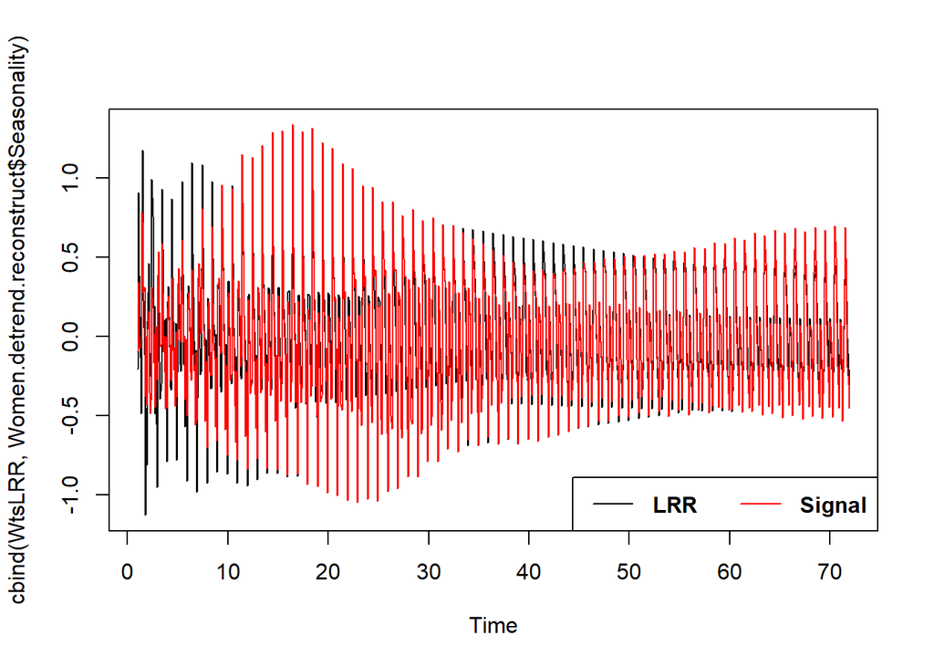

```r
WtsLRR<-ts(as.numeric(W.full%*%C),frequency = 12)
plot.ts(cbind(WtsLRR,Women.detrend.reconstruct$Seasonality), plot.type = 'single',col = c('black', 'red'))
legend("bottomright",paste(c("LRR","Signal")), col = c('black', 'red'),lty=1,lw=c(1,1),text.font = 2,horiz=TRUE)
```

Кажется, что сгенерированный по формуле ряд слишком грубо оценивает сезонность. Сезонность, которую мы выделили, имеет более сложную форму и это соответствует виду исходного ряда:

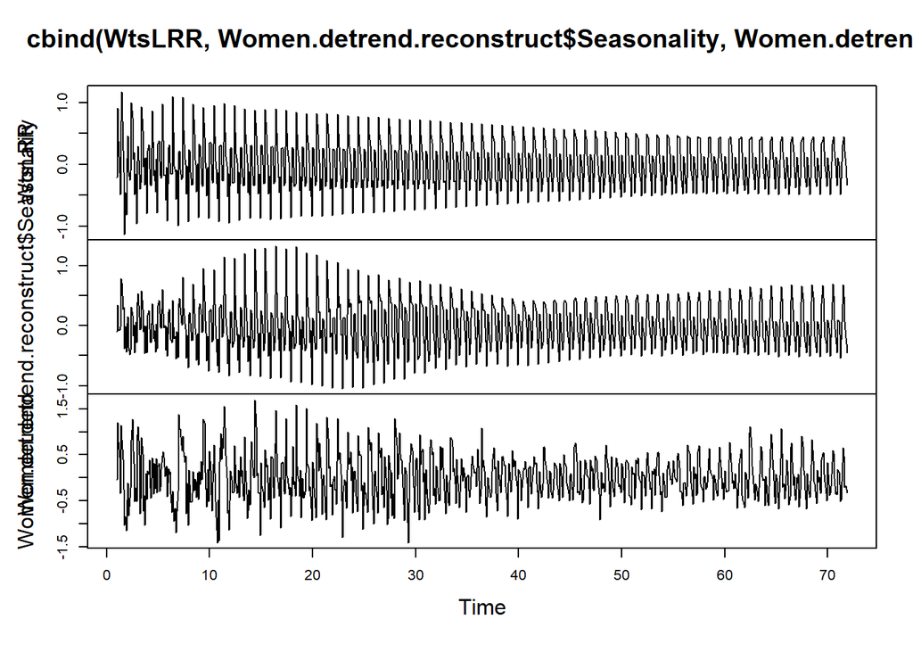

```r
plot.ts(cbind(WtsLRR,Women.detrend.reconstruct$Seasonality,Women.detrend))
```